# Session 3 : Geoprocessing with vectors

Author

Kristof Van Oost & Valentin Charlier

## Today’s program

- Last week’s assignment: discussion
- Geoprocessing
- Exercise all together

## Today’s Learning Objectives

- Knowing how to manipulate spatial object in R

## Additional resources

- The book “Geocomputation in R” (https://geocompr.robinlovelace.net/)
- sf pkg [vignette] (https://cran.r-project.org/web/packages/sf/vignettes/sf1.html)
- Spatial data manipulation in [R](https://www.rspatial.org/)
- Example on spatial data manipulation [here] (https://fukamilab.github.io/BIO202/08-A-mapping.html) and [here] (https://nceas.github.io/oss-lessons/spatial-data-gis-law/3-mon-intro-gis-in-r.html)
- Plots your data using [ggplot2](http://r-statistics.co/Complete-Ggplot2-Tutorial-Part1-With-R-Code.html)
- dataframes manipulation using [reshape2](https://seananderson.ca/2013/10/19/reshape/)

## Geoprocessing

```r
install.packages("sp")
install.packages("raster")
install.packages("terra")
install.packages("geodata")
install.packages("sf")
```

Let’s set our working directory and load the packages into the global environment.

```r
setwd("C:/Users/valcharlier/Desktop/Assistanat Géographie/Q2/LGEO2185 Géoprocessing/TP3")
library(sp) #vector
library(terra) # Update of raster
library(geodata)# Update of getData
library(sf)#simple features
library(raster)
```

We will use the geodata::gadm function from the geodata package. Type ?geodata to see the help for this function of the geodata package. We can now easily get data from different online sources such as the Global Administrative Area Data base.

We can get data using the geodata function from the geodata package. Type help(geodata) to see what is possible. Let’s download a Spatial Vector DataFrame:

```r
France_SVDF <- geodata::gadm("GADM", country = "FRA", level = 2, download = TRUE)
```

In R we can do all the geoprocessing operations that we can normally do in a GIS standalone software.

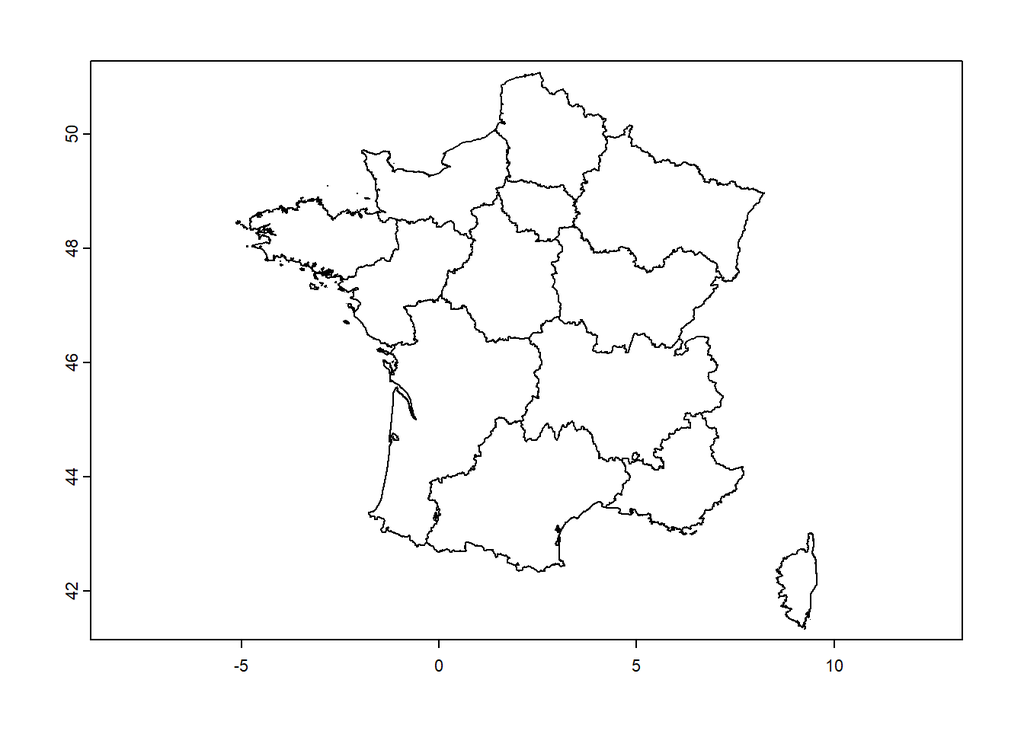

```r
plot(pa)
```

**Difference** Let’s now load a general polygon (available in the “Session 3” Materials folder )

```r
pol<-vect("data/fr_poly.shp")
pol
```

```
 class       : SpatVector
 geometry    : polygons
 dimensions  : 1, 1  (geometries, attributes)
 extent      : -0.3601271, 6.264925, 44.67336, 49.09483  (xmin, xmax, ymin, ymax)
 source      : fr_poly.shp
 coord. ref. : lon/lat WGS 84 (EPSG:4326)
 names       :    id
 type        : <int>
 values      :     1
```

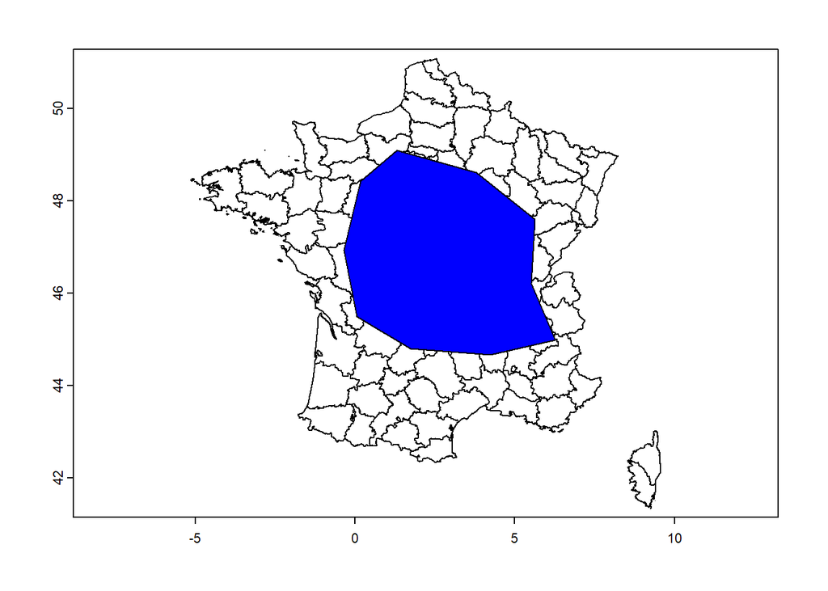

```r
plot(France_SVDF)
plot(pol, add=T, col="blue")
```

We can then compute the difference between two polygons

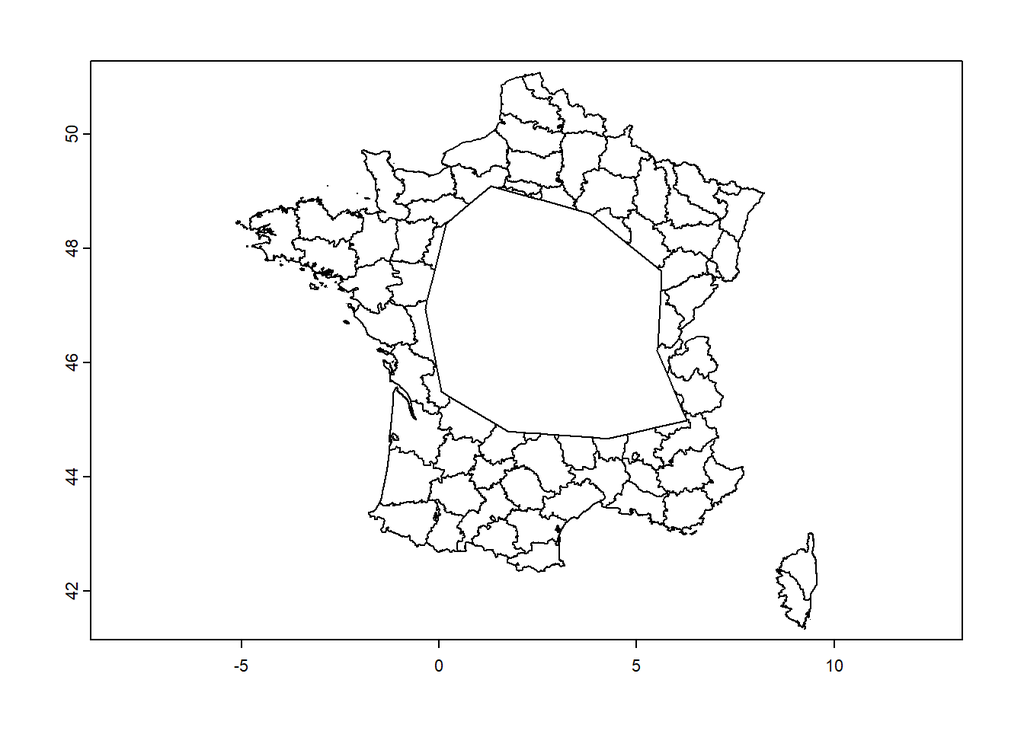

```r
#erase or difference
e <- erase(France_SVDF, pol)
# equivalent to
e <- France_SVDF -pol
plot(e)
```

**Intersect** The intersection

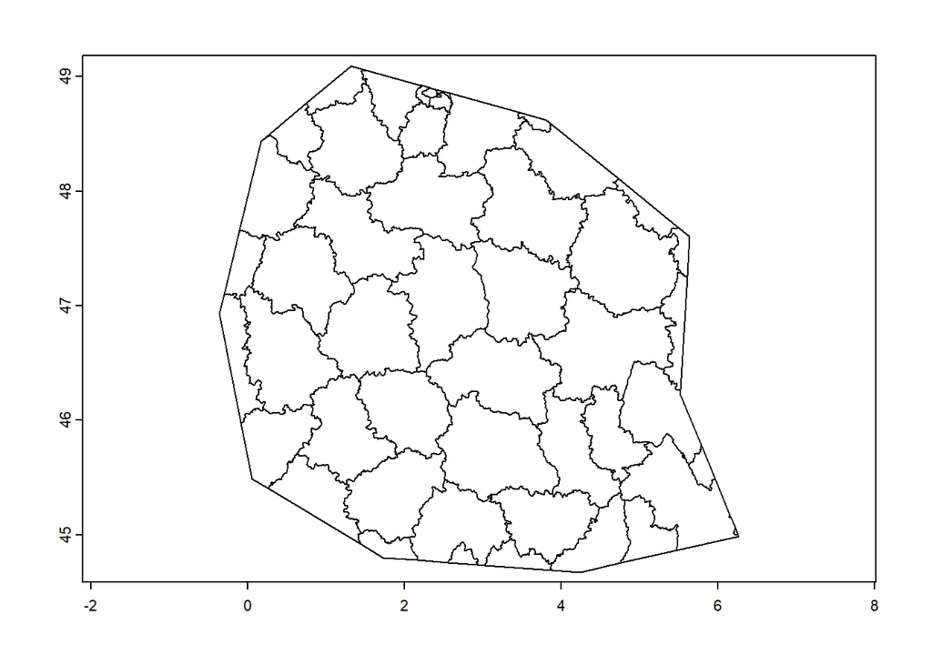

```r
i <- intersect(France_SVDF, pol)
plot(i)
```

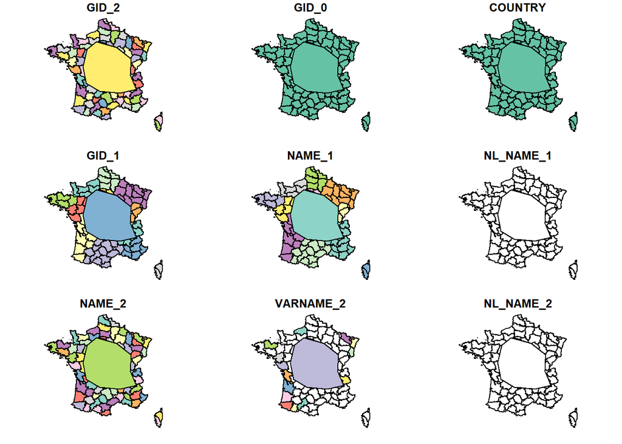

```r
pol_sf<-st_as_sf(pol)
Fra_sf<-st_as_sf(France_SVDF)

sf_use_s2(FALSE)
U<-st_union(Fra_sf,pol_sf)
plot(U)
```